# checkin data: global analysis

Ming Li

Wednesday, August 13, 2014

Based on the summarization of previous work, we want to perform similar exploratory analysis in a global scale.

The assumption is: despite the sparsity of any single users, the gloabl dataset will express some relevant patterns that might be hidden from single users, because of **LLN**.

#### 1. chi-square for temporal and meteorological

Load the data.

```r
## checkin data
## nrows=529931 ~~ 19 weeks/133 days's data
checkin.global = read.csv( paste0(basedir, "data\\allcheckins.csv"),
                       header=TRUE, sep=",", nrows=529931, na.strings = "none",
                       colClasses = c("numeric","numeric","factor","factor", "numeric","numeric",
                                      "numeric","character","factor","factor")
)
checkin.global$datetime = strptime( strtrim(checkin.global$localtime,19), format="%Y-%m-%d %H:%M:%S")

## weather data
weather = read.csv( paste0(basedir, "data\\weather.csv"),
                       header=TRUE, sep=",", na.strings = c("-9999","Unknown"),
                       colClasses = c("numeric","numeric","numeric","character","numeric","factor",
                                      "numeric","numeric","numeric","numeric","numeric","numeric",
                                      "numeric","numeric")
)
## deal with logical data
weather$fog=as.logical(weather$fog)
weather$rain=as.logical(weather$rain)
weather$snow=as.logical(weather$snow)
weather$thunder=as.logical(weather$thunder)
weather$tornado=as.logical(weather$tornado)

## join checkin data with weather data based on timestamps
checkin.global = joindfsbytime(checkin.global, weather)

## deal with time
checkin.global$hour = as.factor(format(checkin.global$datetime,"%H"))
checkin.global$yearday = format(checkin.global$datetime,"%j")
checkin.global$weekday = format(checkin.global$datetime,"%w")
checkin.global$isweekend = as.factor(ifelse( ( checkin.global$weekday>5 ), "Saturday",
    ifelse( ( checkin.global$weekday<1 ),"Sunday","Workday")))

## add record for last checkin
# checkin.global = copylastcheckinrec(checkin.global)
checkin.global = checkin.global[complete.cases(checkin.global$conds),]
```

Again, chi-square test:

```r
# venue_cate v.s. hour of day
cate.hour = xtabs(~hour+cate_l1, data=checkin.global)
chisq.test(cate.hour)
```

```
##
##  Pearson's Chi-squared test
##
## data:  cate.hour
## X-squared = 132062, df = 207, p-value < 2.2e-16
```

```r
# venue_cate v.s. weekend/workday
cate.weekend = xtabs(~isweekend+cate_l2, data=checkin.global)
chisq.test(cate.weekend)
```

```
##
##  Pearson's Chi-squared test
##
## data:  cate.weekend
## X-squared = 31567, df = 756, p-value < 2.2e-16
```

```r
# venue_cate v.s. weather condition
cate.conds = xtabs(~conds+cate_l1, data=checkin.global)
cate.conds = as.table(cate.conds[rowSums(cate.conds)>0,colSums(cate.conds)>0])
chisq.test(cate.conds)
```

```
##
##  Pearson's Chi-squared test
##
## data:  cate.conds
## X-squared = 3216, df = 117, p-value < 2.2e-16
```

```r
#### interactions between factors
# hour v.s. weekend/workday
hour.isweekend = xtabs(~hour+isweekend, data=checkin.global)
chisq.test(hour.isweekend)
```

```
##
##  Pearson's Chi-squared test
##
## data:  hour.isweekend
## X-squared = 25317, df = 46, p-value < 2.2e-16
```

```r
# hour v.s. weather condition
hour.conds = xtabs(~hour+conds, data=checkin.global)
hour.conds = as.table(hour.conds[rowSums(hour.conds)>0,colSums(hour.conds)>0])
chisq.test(hour.conds)
```

```
##
##  Pearson's Chi-squared test
##
## data:  hour.conds
## X-squared = 37243, df = 299, p-value < 2.2e-16
```

The results shows that there are some interactions between these factors. The hour-weekend interaction can be explained like this: the number of checkins at a given hour of a given weekday cannot be estimated by the marginal checkins in each hour and marginal checkins in Saturday, sunday and workday; they have differnt patterns of checkins across the hour.

Well, this seems to make things even more complicated. However, we still have to move on.

category with weather:

```r
# the probability of checkin a category under certain weather conditon
cate.conds.p=t(apply(cate.conds, 1, function(x) x/sum(x)  ) )

#cate.conds.p.vec = as.vector(cate.conds.p)
cate.conds.vec = as.vector(cate.conds)
weather.factor = factor(rep(rownames(cate.conds),10))
category.factor = factor(rep(colnames(cate.conds),each=14))

#summary(aov(cate.conds.p.vec~weather.factor))
summary(aov(cate.conds.vec~weather.factor+category.factor))
```

```
##                  Df   Sum Sq  Mean Sq F value  Pr(>F)
## weather.factor   13 6.64e+09 5.11e+08    14.1 < 2e-16 ***
## category.factor   9 1.27e+09 1.41e+08     3.9 0.00024 ***
## Residuals       117 4.24e+09 3.62e+07
## ---
## Signif. codes:  0 '***' 0.001 '**' 0.01 '*' 0.05 '.' 0.1 ' ' 1
```

correspondence analysis

ref:http://www.statmethods.net/advstats/ca.html

```r
library(ca)
prop.table(cate.conds, 1) # row percentages
```

```
##                      cate_l1
## conds                 Arts & Entertainment College & University    Event
##   Clear                           0.101861             0.017618 0.005038
##   Fog                             0.046559             0.025304 0.002024
##   Haze                            0.093115             0.026233 0.004727
##   Heavy Rain                      0.149035             0.013514 0.005792
##   Heavy Snow                      0.000000             0.000000 0.000000
##   Light Freezing Rain             0.037037             0.004630 0.000000
##   Light Rain                      0.117519             0.016183 0.003367
##   Light Snow                      0.105657             0.013955 0.009220
##   Mostly Cloudy                   0.101194             0.017465 0.005972
##   Overcast                        0.107677             0.018207 0.004662
##   Partly Cloudy                   0.114640             0.018503 0.005910
##   Rain                            0.130571             0.017235 0.002263
##   Scattered Clouds                0.098943             0.018828 0.007371
##   Snow                            0.073097             0.025952 0.005623
##                      cate_l1
## conds                     Food Nightlife Spot Outdoors & Recreation
##   Clear               0.296071       0.124188              0.070688
##   Fog                 0.348178       0.061741              0.058704
##   Haze                0.259020       0.094690              0.052151
##   Heavy Rain          0.266795       0.191120              0.030888
##   Heavy Snow          0.083333       0.333333              0.083333
##   Light Freezing Rain 0.180556       0.023148              0.101852
##   Light Rain          0.290757       0.148202              0.046432
##   Light Snow          0.272116       0.104909              0.070272
##   Mostly Cloudy       0.302727       0.109475              0.069002
##   Overcast            0.288940       0.120485              0.058022
##   Partly Cloudy       0.303785       0.120656              0.069403
##   Rain                0.307625       0.156511              0.041086
##   Scattered Clouds    0.311318       0.095573              0.078851
##   Snow                0.231834       0.042388              0.097751
##                      cate_l1
## conds                 Professional & Other Places Residence Shop & Service
##   Clear                                  0.094189  0.028155       0.155553
##   Fog                                    0.153846  0.027328       0.169028
##   Haze                                   0.147708  0.024579       0.169608
##   Heavy Rain                             0.084170  0.036680       0.106950
##   Heavy Snow                             0.333333  0.083333       0.083333
##   Light Freezing Rain                    0.245370  0.060185       0.199074
```

[output cut: 9 more lines]

```
## conds                 Travel & Transport
##   Clear                         0.106640
##   Fog                           0.107287
##   Haze                          0.128171
##   Heavy Rain                    0.115058
##   Heavy Snow                    0.000000
##   Light Freezing Rain           0.148148
##   Light Rain                    0.105626
##   Light Snow                    0.126339
##   Mostly Cloudy                 0.102527
##   Overcast                      0.112787
##   Partly Cloudy                 0.097474
##   Rain                          0.106198
##   Scattered Clouds              0.094857
##   Snow                          0.142734
```

```r
prop.table(cate.conds, 2) # column percentages
```

```
##                      cate_l1
## conds                 Arts & Entertainment College & University     Event
##   Clear                          4.715e-01            4.731e-01 4.772e-01
##   Fog                            8.334e-04            2.628e-03 7.416e-04
##   Haze                           2.141e-02            3.500e-02 2.225e-02
##   Heavy Rain                     6.993e-03            3.679e-03 5.562e-03
##   Heavy Snow                     0.000e+00            0.000e+00 0.000e+00
##   Light Freezing Rain            1.449e-04            1.051e-04 0.000e+00
##   Light Rain                     3.921e-02            3.133e-02 2.299e-02
##   Light Snow                     7.682e-03            5.887e-03 1.372e-02
##   Mostly Cloudy                  7.705e-02            7.716e-02 9.307e-02
##   Overcast                       2.569e-01            2.521e-01 2.277e-01
##   Partly Cloudy                  5.905e-02            5.529e-02 6.229e-02
##   Rain                           1.359e-02            1.041e-02 4.820e-03
##   Scattered Clouds               4.256e-02            4.699e-02 6.489e-02
##   Snow                           3.062e-03            6.307e-03 4.820e-03
##                      cate_l1
## conds                      Food Nightlife Spot Outdoors & Recreation
##   Clear               4.862e-01      4.972e-01             5.179e-01
##   Fog                 2.211e-03      9.560e-04             1.663e-03
##   Haze                2.114e-02      1.884e-02             1.899e-02
##   Heavy Rain          4.442e-03      7.757e-03             2.294e-03
##   Heavy Snow          6.429e-06      6.269e-05             2.868e-05
##   Light Freezing Rain 2.507e-04      7.836e-05             6.310e-04
##   Light Rain          3.442e-02      4.277e-02             2.452e-02
##   Light Snow          7.020e-03      6.598e-03             8.088e-03
##   Mostly Cloudy       8.179e-02      7.210e-02             8.317e-02
##   Overcast            2.446e-01      2.487e-01             2.192e-01
##   Partly Cloudy       5.552e-02      5.375e-02             5.658e-02
##   Rain                1.136e-02      1.409e-02             6.768e-03
##   Scattered Clouds    4.751e-02      3.556e-02             5.369e-02
##   Snow                3.446e-03      1.536e-03             6.482e-03
##                      cate_l1
## conds                 Professional & Other Places Residence Shop & Service
##   Clear                                 4.585e-01 5.010e-01      4.788e-01
##   Fog                                   2.897e-03 1.881e-03      2.012e-03
##   Haze                                  3.573e-02 2.173e-02      2.594e-02
##   Heavy Rain                            4.154e-03 6.617e-03      3.337e-03
##   Heavy Snow                            7.622e-05 6.966e-05      1.205e-05
##   Light Freezing Rain                   1.010e-03 9.055e-04      5.180e-04
```

[output cut: 9 more lines]

```
## conds                 Travel & Transport
##   Clear                        4.789e-01
##   Fog                          1.863e-03
##   Haze                         2.860e-02
##   Heavy Rain                   5.239e-03
##   Heavy Snow                   0.000e+00
##   Light Freezing Rain          5.625e-04
##   Light Rain                   3.419e-02
##   Light Snow                   8.913e-03
##   Mostly Cloudy                7.575e-02
##   Overcast                     2.611e-01
##   Partly Cloudy                4.871e-02
##   Rain                         1.072e-02
##   Scattered Clouds             3.959e-02
##   Snow                         5.801e-03
```

```r
fit <- ca(cate.conds)
print(fit) # basic results
```

```
##
##  Principal inertias (eigenvalues):
##            1        2       3        4        5       6       7
## Value      0.003175 0.00195 0.000545 0.000175 8.4e-05 6.3e-05 5.7e-05
## Percentage 52.16%   32.04%  8.95%    2.87%    1.38%   1.03%   0.94%
##            8       9
## Value      2.7e-05 1.1e-05
## Percentage 0.44%   0.18%
##
##
##  Rows:
##             Clear       Fog      Haze Heavy Rain Heavy Snow
## Mass     0.483522  0.001870  0.024025   0.004902   0.000023
## ChiDist  0.028982  0.327464  0.215717   0.323466   1.211348
## Inertia  0.000406  0.000201  0.001118   0.000513   0.000033
## Dim. 1   0.214951 -4.584354 -3.037591   4.503458  -1.534756
## Dim. 2  -0.422001  0.128074  2.814400   4.071209  10.678418
##         Light Freezing Rain Light Rain Light Snow Mostly Cloudy  Overcast
## Mass               0.000409    0.03485   0.007595      0.079543  0.249277
## ChiDist            0.694485    0.12563   0.137614      0.056361  0.042680
## Inertia            0.000197    0.00055   0.000144      0.000253  0.000454
## Dim. 1           -10.182340    1.71823  -0.989541     -0.584982 -0.092711
## Dim. 2             3.833152    1.70139   0.886942     -0.785304  0.904782
##         Partly Cloudy     Rain Scattered Clouds      Snow
## Mass         0.053804 0.010871          0.04493  0.004376
## ChiDist      0.064818 0.203850          0.11931  0.453735
## Inertia      0.000226 0.000452          0.00064  0.000901
## Dim. 1       0.512216 3.318525         -1.21399 -7.329588
## Dim. 2      -0.925001 1.465850         -2.01617  2.226647
##
##
##  Columns:
##         Arts & Entertainment College & University     Event      Food
## Mass                0.104464             0.018005  0.005104  0.294412
## ChiDist             0.069371             0.089178  0.167862  0.034082
## Inertia             0.000503             0.000143  0.000144  0.000342
## Dim. 1              0.968852            -1.102140 -1.050339  0.221491
## Dim. 2              0.503647             0.543120 -2.320821 -0.616601
##         Nightlife Spot Outdoors & Recreation Professional & Other Places
## Mass          0.120769              0.065992                    0.099320
## ChiDist       0.106456              0.127843                    0.125242
## Inertia       0.001369              0.001079                    0.001558
## Dim. 1        1.790745             -0.819744                   -1.895650
## Dim. 2        0.578032             -2.427488                    1.445576
##         Residence Shop & Service Travel & Transport
## Mass      0.02717       0.157100           0.107664
## ChiDist   0.09787       0.043942           0.059912
## Inertia   0.00026       0.000303           0.000386
## Dim. 1    0.52009      -0.539896          -0.412600
## Dim. 2    1.05165      -0.442939           1.103566
```

```r
summary(fit) # extended results
```

```
##
## Principal inertias (eigenvalues):
##
##  dim    value      %   cum%   scree plot
##  1      0.003175  52.2  52.2  *************************
##  2      0.001950  32.0  84.2  ***************
##  3      0.000545   8.9  93.1  ****
##  4      0.000175   2.9  96.0  *
##  5      8.4e-050   1.4  97.4  *
##  6      6.3e-050   1.0  98.4
##  7      5.7e-050   0.9  99.4
##  8      2.7e-050   0.4  99.8
##  9      1.1e-050   0.2 100.0
##         -------- -----
##  Total: 0.006087 100.0
```

[output cut: 31 more lines]

```r
#plot(fit) # symmetric map
ppi <- 300
png(paste0(basedir,"img\\plot_weather_category_correspondence2.png"), width = 8*ppi, height = 6*ppi, res=ppi)
plot(fit, mass = TRUE, contrib = "absolute", map =
   "rowgreen", arrows = c(TRUE, FALSE)) # asymmetric map
dev.off()
```

#### 2. (temporal weighted) sequential factor

Now consider the sequential factor. The hypothesis is two categories can be more connected if they are usually checked in consecutively. Basically, this should be done by 2nd level category, right? because the 1st level cannot give too much information.

The foundation approach here is Markov chain.

first, we should create a data frame that describe the sequences:

```r
sequence.list = lapply(split(checkin.global, checkin.global$user_id), function(i){
    if(nrow(i)>30)
        copylastcheckinrec(i, samesize=FALSE)
})
sequence.list[sapply(sequence.list, is.null)] = NULL
sequence.global <- as.data.frame( do.call("rbind", sequence.list) )
sequence.global$weight <- exp( -2 * sequence.global$time_diff / 60 )
#temp <- lapply(sequence.list, function(i) sequence.global<<-rbind(sequence.global, i))
```

Note: `do.call("rbind", sequence.list)` combines all the data frame in the list into a data frame.

markov chain is based on contingency table; we’d like to do similarly, but the contingency table should be temporally weighted:

```r
unique.cates <- sort(unique(sequence.global$last_cate))
levels.cates <- levels(checkin.global$cate_l2)
transition.matrix <- matrix(0,nrow=length(unique.cates),  ncol=length(unique.cates),
                            dimnames=list(levels.cates[unique.cates],
                                          levels.cates[unique.cates]));
temp = lapply(split(sequence.global, sequence.global$last_cate), function(lst){
    total.sum <- sum(lst$weight)
    transition.matrix[ levels.cates[unique(lst$last_cate)],
                       levels.cates[sort(unique(lst$cate))] ] <<-
        sapply( split(lst, lst$cate), function(cur){
            if(total.sum!=0) { p = sum(cur$weight) / total.sum }
            else { p = 1/length(unique(lst$cate)) }  ## for all zeros
            p
        })
    NA
})
rm(temp)
```

```r
# just in case:
# save(transition.matrix,file="D:\\Experiments\\R\\data\\transition.matrix_0814.Rda")
load("D:\\Experiments\\R\\data\\transition.matrix_0814.Rda")
library(markovchain)
mcSequence <- new("markovchain",
                 states = levels.cates[unique(sequence.global$last_cate)],
                 transitionMatrix = transition.matrix,
                 name = "sequence")
predict(object = mcSequence, newdata = c("American Restaurant"),n.ahead = 3)
```

update @ 2014.09.05

3. correspondence analysis for hour

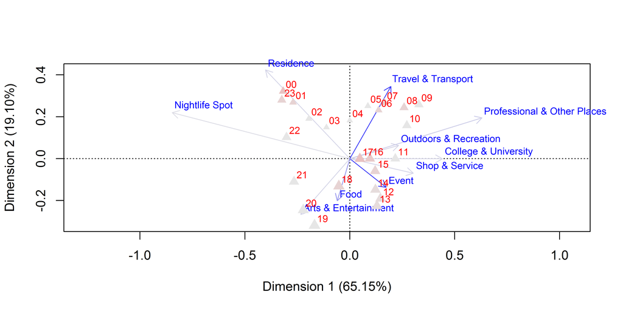

```r
hour.cate= xtabs(~cate_l1+hour,data=checkin.global)
fit.hour.cate=ca(hour.cate)
plot(fit.hour.cate, mass = TRUE, contrib = "absolute", map =
                "rowgreen", arrows = c(TRUE, FALSE)) # asymmetric map
```

the points of `hour` can be connected clockwisely. And some of them are much more closer and form some clusters. Next thought: it should be possible to aggreate similar hours in the same *cluster*. In this way, the levels in the `hour` can be depressed, and each level can describe more final varience.

- step 0: get the coordinates of the `hour` point.
- step 1: how many clusters?
- step 2: k-means clustering

ref: http://www.statmethods.net/advstats/cluster.html

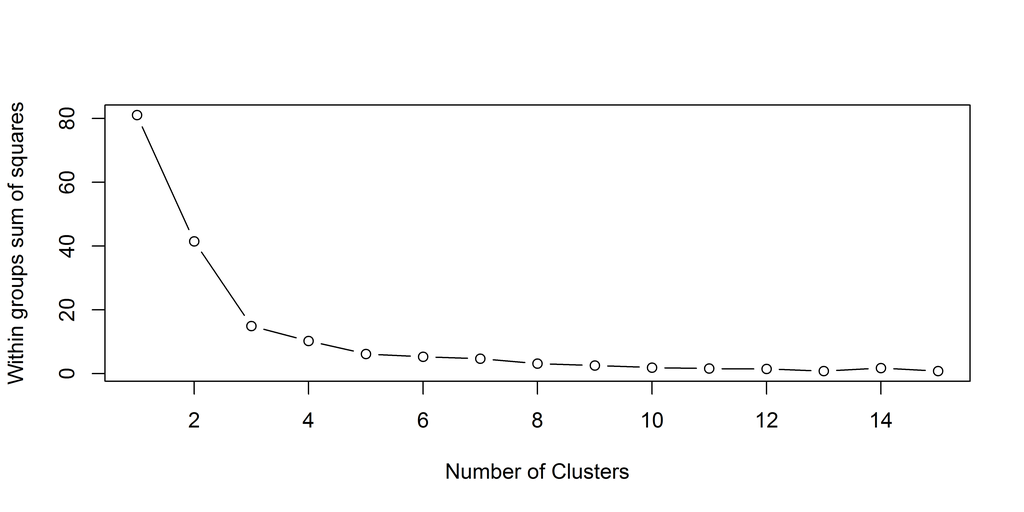

```r
# get coordinates
hour.coords = fit.hour.cate[["colcoord"]][,1:2]
# Determine number of clusters
wss <- (nrow(hour.coords)-1)*sum(apply(hour.coords,2,var))
for (i in 2:15) wss[i] <- sum(kmeans(hour.coords,
   centers=i)$withinss)
plot(1:15, wss, type="b", xlab="Number of Clusters",
  ylab="Within groups sum of squares")
```

```r
# K-Means Cluster Analysis
kmeansclusters <- kmeans(hour.coords,6) # 6 cluster solution
# get cluster means
aggregate(hour.coords,by=list(kmeansclusters$cluster),FUN=mean)
```

```
##   Group.1      V1      V2
## 1       1  0.5328 -0.3579
## 2       2 -1.4804  0.5017
## 3       3 -0.6500 -0.6951
## 4       4 -2.0794  2.1289
## 5       5  0.5085  2.9369
## 6       6  1.4052  1.5157
```

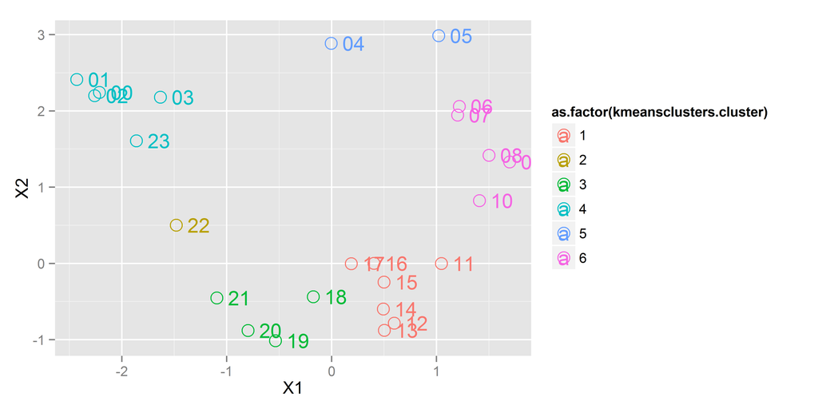

```r
# append cluster assignment
hour.coords <- data.frame(hour=fit.hour.cate[["colnames"]],
                          hour.coords, kmeansclusters$cluster)

# plot cluster
ggplot(data=hour.coords, aes(x=X1,y=X2,color=as.factor(kmeansclusters.cluster)))+
    geom_point( size=4, shape=21)+
    geom_text(aes(label=hour),hjust=-0.5, vjust=0.5)
```

similar work can also be done with weather condition

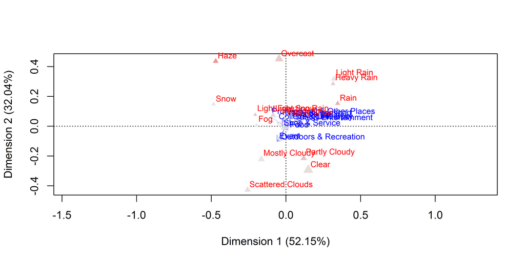

```r
conds.cate= xtabs(~cate_l1+conds,data=checkin.global)
fit.conds.cate=ca(conds.cate)
plot(fit.conds.cate, mass = TRUE, contrib = "absolute", map =
                "rowgreen", arrows = c(TRUE, FALSE)) # asymmetric map
```

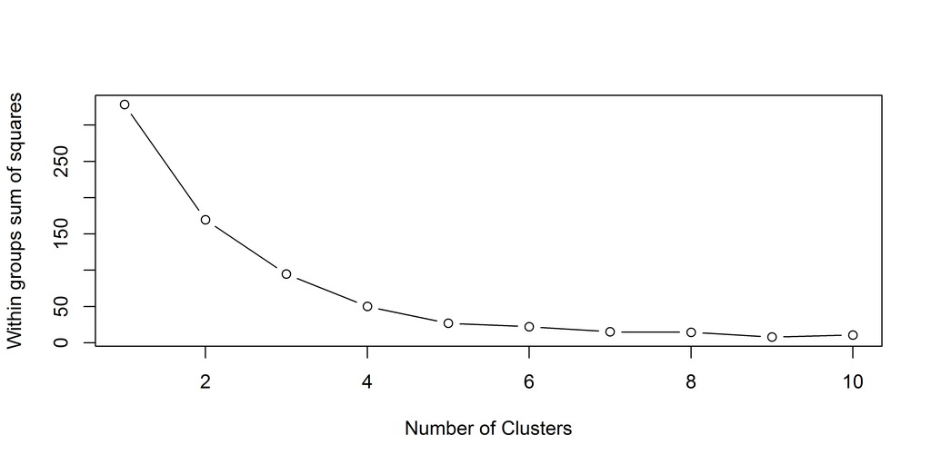

```r
# get coordinates
conds.coords = fit.conds.cate[["colcoord"]][,1:2]
# Determine number of clusters
wss <- (nrow(conds.coords)-1)*sum(apply(conds.coords,2,var))
for (i in 2:10) wss[i] <- sum(kmeans(conds.coords,
   centers=i)$withinss)
plot(1:10, wss, type="b", xlab="Number of Clusters",
  ylab="Within groups sum of squares")
```

```r
# K-Means Cluster Analysis
kmeansclusters <- kmeans(conds.coords,5) # 5 cluster solution
# get cluster means
aggregate(conds.coords,by=list(kmeansclusters$cluster),FUN=mean)
```

```
##   Group.1     V1      V2
## 1       1 -1.535 10.6784
## 2       2 -3.811  1.4712
## 3       3 -0.359 -0.3928
## 4       4  3.180  2.4128
## 5       5 -8.756  3.0299
```

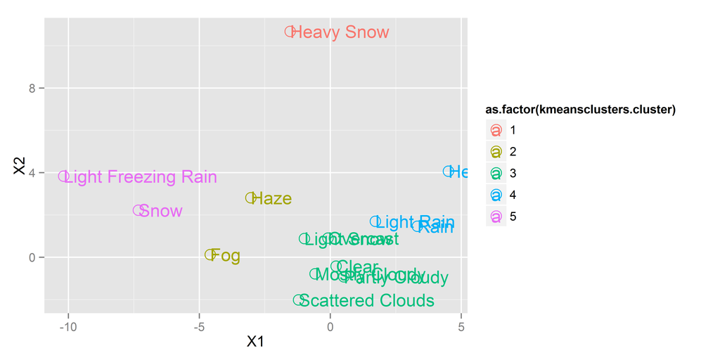

```r
# append cluster assignment
conds.coords <- data.frame(conds=fit.conds.cate[["colnames"]],
                          conds.coords, kmeansclusters$cluster)

# plot cluster
ggplot(data=conds.coords, aes(x=X1,y=X2,color=as.factor(kmeansclusters.cluster)))+
    geom_point( size=4, shape=21)+
    geom_text(aes(label=conds),hjust=-0., vjust=0.5)
```